# Untitled

Shan Chen

2/24/2020

```r
library(tidyverse)
```

- *age* is age of volunteer
- *score* is composite kidney health score.

```r
fileName<-"kidneyCASI.csv"
```

```r
kidney.df <- read.csv("kidneyCASI.csv")
N <- nrow(kidney.df)
```

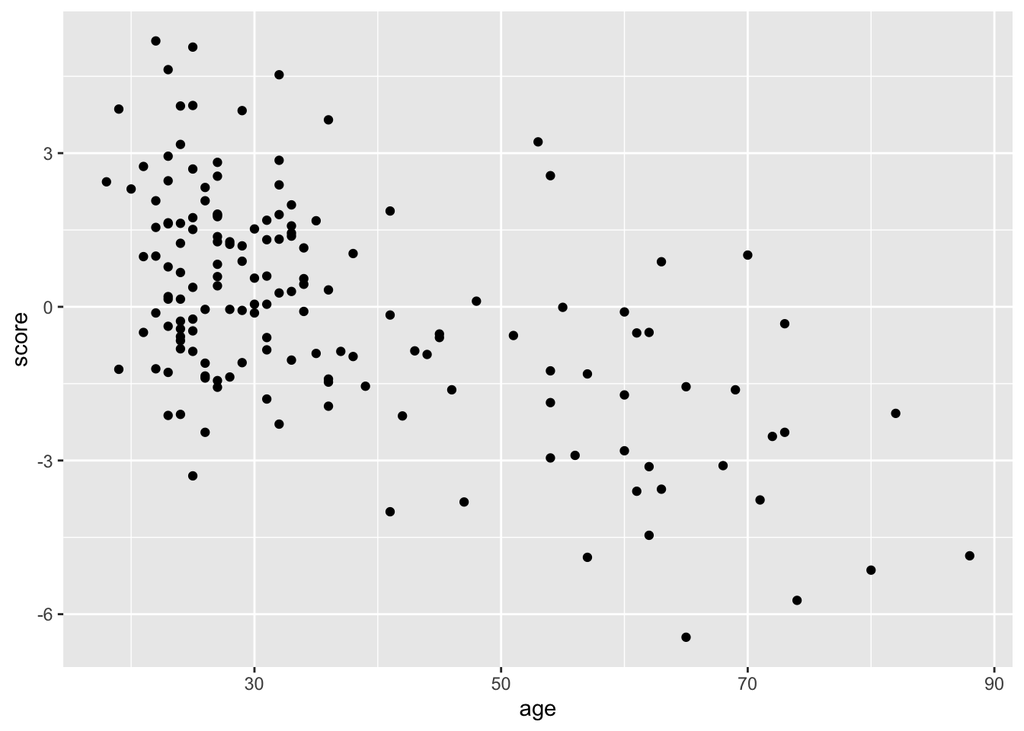

```r
ggplot(kidney.df)+
    geom_point(aes(age,score))
```

Note: Kidneys start to deteriorate as people get older (ARGH)!

Assess the utility of both lm and loess as a predictive tool prediction for the score. Use MSE as the loss function.

For loess, estimate an optimal value for the span.

```r
mselm <- function(theFormula,numBoots){
  msevals <- array(numeric(0),numBoots)
  for (m in 1:numBoots){
    bootSample <- sample(1:N,N,rep=T)
    train.df <- kidney.df[bootSample,] ##training bootstrap data

    bootSample <- sample(1:N,N,rep=T)
    test.df <- kidney.df[bootSample,] ##creating bootstrap test data
    ##build model and predict
    mod.lm <- lm(formula(theFormula),data = train.df)
    test.df$pred <- predict(mod.lm,newdata = test.df)

    msevals[m] <- with(test.df,mean((score-pred)^2,na.rm = T))
  }
  ##value return
  c(mean(msevals),sd(msevals))
}
```

```r
##run the function
theFormula <- "score ~ age"
numBoots <- 100
mselm(theFormula, numBoots)
```

```
## [1] 3.2649539 0.3503985
```

```r
mseLoess <- function(theSpan,numBoots){
  mseVals <- array(numeric(0),numBoots)
  ###
  m <- 1
  for(m in 1:numBoots){
    ## bootstrap for training data
    bootSample <- sample(1:N,N,rep=T)
    train.df <- kidney.df[bootSample,]

    ## bootstrap again for testing data
    bootSample <- sample(1:N,N,rep=T)
    test.df <- kidney.df[bootSample,]
    ##model and predict
    mod.lo <- loess(score~age,data=train.df,span=theSpan)
    test.df$pred <- predict(mod.lo,newdata=test.df)
    ##save the mse values
    mseVals[m] <- with(test.df,mean((score-pred)^2,na.rm=T))
  }
  # Return the mean and sd of the mseVals
  c(mean(mseVals),sd(mseVals))
}
```

```r
theSpan <- 3
numBoots <- 100
mseLoess(theSpan, numBoots)
```

```
## [1] 3.241423 0.366803
```

For lm, allow higher order terms (up to age^3)

```r
numBoots <- 1000
```

### Linear models

Linear models using up to cubic terms

```r
theFormula1 <- "score ~ age"
theFormula2 <- "score ~ age + I(age^2)"
theFormula3 <- "score ~ age + I(age^2) + + I(age^3)"

mse.lm1 <- mselm(theFormula1, numBoots)
mse.lm2 <- mselm(theFormula2, numBoots)
mse.lm3 <- mselm(theFormula3, numBoots)
```

```r
c(mse.lm1[1],mse.lm2[1],mse.lm3[1])
```

```
## [1] 3.228999 3.253619 3.321638
```

Not much difference between these three linear models even we raise its to cubic terms.

Experiment with the span values to find a decent range

```r
theSpan <- .30
theSpan <- 3
mseLoess(theSpan, numBoots)
```

```
## [1] 3.2858250 0.3627497
```

```r
numSpans <- 100
minSpan <- .3
maxSpan <- 5
spanVals <- seq(minSpan,maxSpan,length=numSpans)
## store the mean and standard deviation of the mse for each spanVal
spanMSEVals <- matrix(nrow=numSpans,ncol=2)
k <- 1
for(theSpan in spanVals){
  spanMSEVals[k,] <- mseLoess(theSpan,numBoots)
  print(c(theSpan,spanMSEVals[k,1]))
  k <- k+1
}
```

```
## [1] 0.300000 3.297202
## [1] 0.3474747 3.2961464
## [1] 0.3949495 3.3004754
## [1] 0.4424242 3.2752425
## [1] 0.489899 3.263226
## [1] 0.5373737 3.2729839
## [1] 0.5848485 3.2669882
## [1] 0.6323232 3.2679989
## [1] 0.679798 3.257140
## [1] 0.7272727 3.2582688
## [1] 0.7747475 3.2784341
## [1] 0.8222222 3.2705292
## [1] 0.869697 3.306982
## [1] 0.9171717 3.2814936
## [1] 0.9646465 3.2906444
```

[output cut: 85 more lines]

In particular, summarize the difference in predictions and the standard error of prediction for each algorithms. Use bootstrapping for both algorithms. Are there any marked differences between these two algorithms? Is there any reason to favor one method over the other based on MSE?

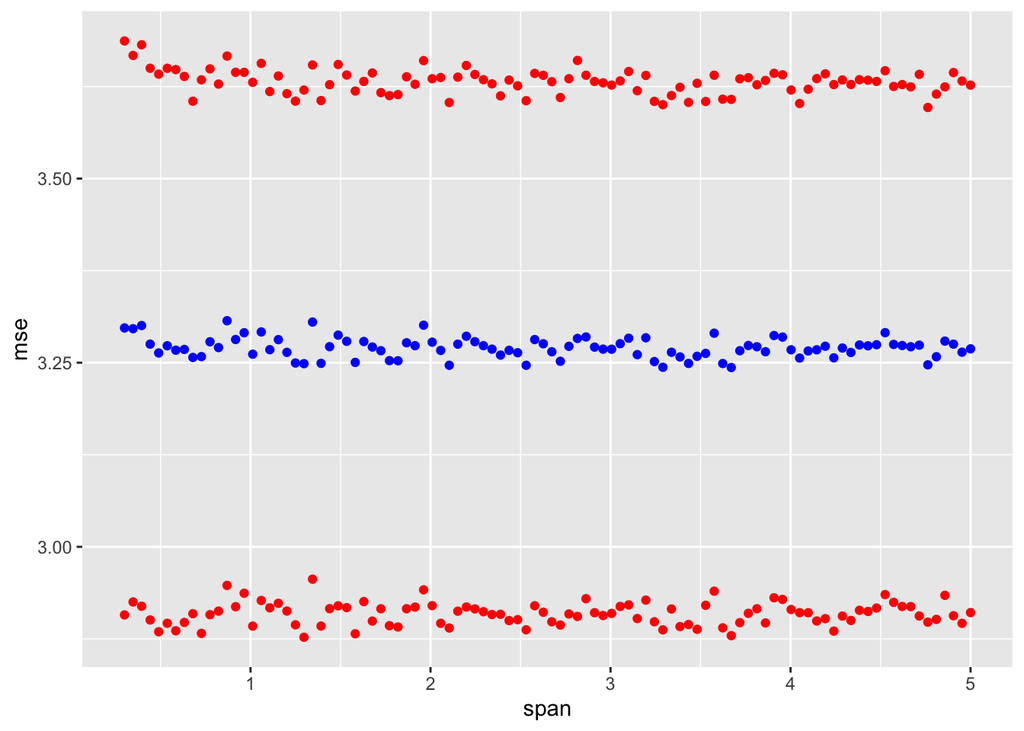

```r
##display data
data.frame(span=spanVals,mse=spanMSEVals[,1],sdev=spanMSEVals[,2]) %>%
  ggplot()+
  geom_point(aes(span,mse),color="blue")+
    geom_point(aes(span,mse+sdev),color="red")+
      geom_point(aes(span,mse-sdev),color="red")
```

Really small changes. Span has very little effect on changes in mse.

## Conclusion

Between a simple linear model and a loess model of varying span, the best choice of model appears to be the most basic linear model. score ~ age For almost every model we looked at the MSE is approximately

```r
mse.lm1[1]
```

```
## [1] 3.228999
```

A 95% coverage interval, based on boostrapping is roughly

```r
c(mse.lm1[1]-2*mse.lm1[2],mse.lm1[1]+2*mse.lm1[2])
```

```
## [1] 2.515870 3.942129
```

As value, loses and lm do not share large differences, they have really similar mse values.